# Linear Models - Linear Regression

Elizabeth Oladapo

Last modified: 10 Oct 2023

In this session, we will guide you through the process of performing a simple linear regression. Regressions are some of the most commonly used models in data science. These models are distinguished by the presence of a response variable, which is what we aim to predict, and explanatory variables, which we employ to elucidate variations in the predicted outcome. We will introduce the use of a new package, “ggfortify”.

What sets regression apart as a modeling technique is the nature of the explanatory variables; they are continuous rather than categorical.

We will using the “hypertension” dataset, a fabricated dataset comprising two variables: “cholesterol level” and “blood pressure.” The primary objective is to explore and explain the relationship between these two variables. The fundamental concept here is that an increase in cholesterol levels resulting from a diet rich in cholesterol can lead to elevated blood pressure. This principle forms the basis of our investigation, and it is the idea we intend to quantify. In other words, it revolves around the examination of cholesterol levels and their impact on the occurrence of high blood pressure.

As a reminder, our suggested workflow involves these steps:

- Visualize the data and make guesses
- Build the model
- Evaluate assumptions
- Make inference and Evaluate guesses
- Plot the model to the data

### **Explore the data and make guesses**

Load the “hypertension” dataset and check the structure of our dataset.

It is essential to note that all the variables are numeric; there are no categorical variables in this dataset.

```r
# Load necessary libraries
library(tidyverse)
# Load the "hypertension" dataset
hypertension_data <- read.csv("data/hypertension.csv")

# Explore the structure of the dataset using str()
str(hypertension_data)
```

```
## 'data.frame':    49 obs. of  2 variables:
##  $ cholesterol_level: num  5.64 6.5 20.38 9.91 10.28 ...
##  $ blood_pressure   : num  128 162 234 181 222 ...
```

It confirms that we have a dataframe with 49 observations and two numeric variables: blood pressure and cholesterol level.

Now, let’s create a scatterplot.

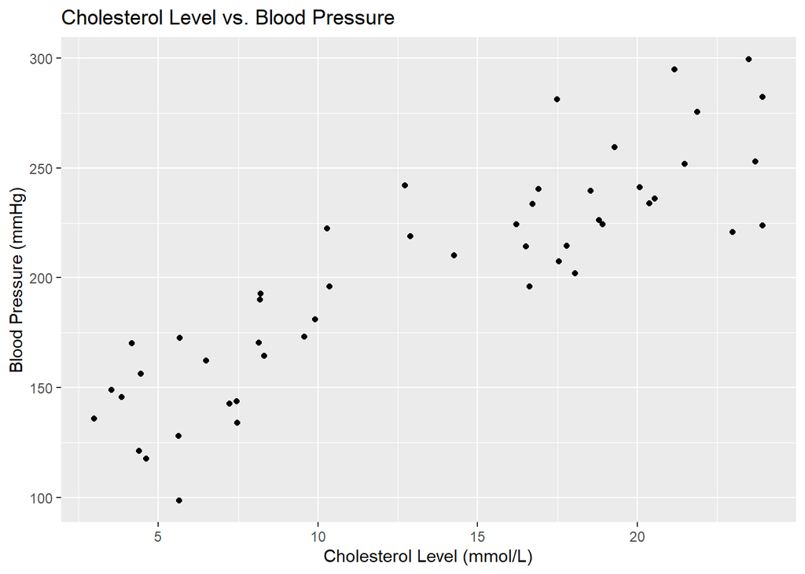

```r
# Create a scatterplot to visualize the relationship
ggplot(hypertension_data, aes(x= cholesterol_level , y=blood_pressure )) +
  geom_point() +
  labs(title="Cholesterol Level vs. Blood Pressure", x="Cholesterol Level (mmol/L)", y="Blood Pressure (mmHg)")
```

Let us take a closer look at our scatterplot. The x-axis represents Cholesterol Level, which is essentially the amount of cholestrol in the body, while the y-axis represents Blood Pressure. When examining a scatterplot, there are several key observations we can make.

Firstly, we can assess whether there is a positive relationship between these variables. A positive relationship would imply that as cholesterol level increases, blood pressure also increases. This is indicated by a positive gradient or slope in the line that fits the data. Conversely, a flat line would suggest no relationship (a gradient of zero), and a negative slope would indicate a negative relationship.

In our plot, it appears to be a positive relationship. When there is higher cholesterol level, the blood pressure also tends to increase. So, if you are eating alot of food with high cholesterol level, this is bad news – your are likely to become hypertensive.

Secondly, we can make an educated assumptions about the strength of the relationship between cholesterol level and the blood pressure. It is important to note that the x-axis ranges from 2 to 25, while the y-axis ranges from approximately 100 to 300. Considering these ranges, we can estimate the gradient or slope of the line. The gradient represents the change in blood pressure divided by the change in cholesterol level. In this case, we observe that the blood pressure changes from roughly 100 to 300, which is a possible 200 units of change. On the x-axis, the change spans from 0 to 25, which is a 25-unit change. The ratio, then, is equal to 200 divided by 25 (8), which serves as our estimate of the gradient.

Another aspect to consider is the intercept in our linear equation. Recall that our linear equation takes the form of y = mx + b (or c), where ‘m’ represents the gradient and ‘b’ (or ‘c’) is the intercept. We have calculated a value for slope (‘m’) as 8, but what about the intercept?

The intercept represents the point where the line intersects the y-axis when x equals 0. Based on our scatterplot, it appears that this intercept will be just below the value of 150. Let us estimate it as approximately 135. At this juncture, it is a good practice to write down your assumptions. For instance, you could note that your guess is the gradient is 8, and the intercept is 135.

### **Build the model and fit it to the data**

We will be using the lm function to fit the linear model. This choice is because we are dealing with linear models. Note that linear models are sometimes referred to as general linear models. They can contain simple linear regression, multiple regressions, ANOVAs, and ANCOVAs. However, it is important to note that these are different from the GLMs. The use of the acronym for “GLM” is reserved for generalized linear model, which pertains to models where assumptions about the normality of residuals no longer hold.

The structure of our model is straightforward: we have a response variable we are trying to predict, which in this case is blood pressure. We will express this as “blood_pressure ~ cholesterol_level” meaning that blood pressure is a function of cholesterol level.

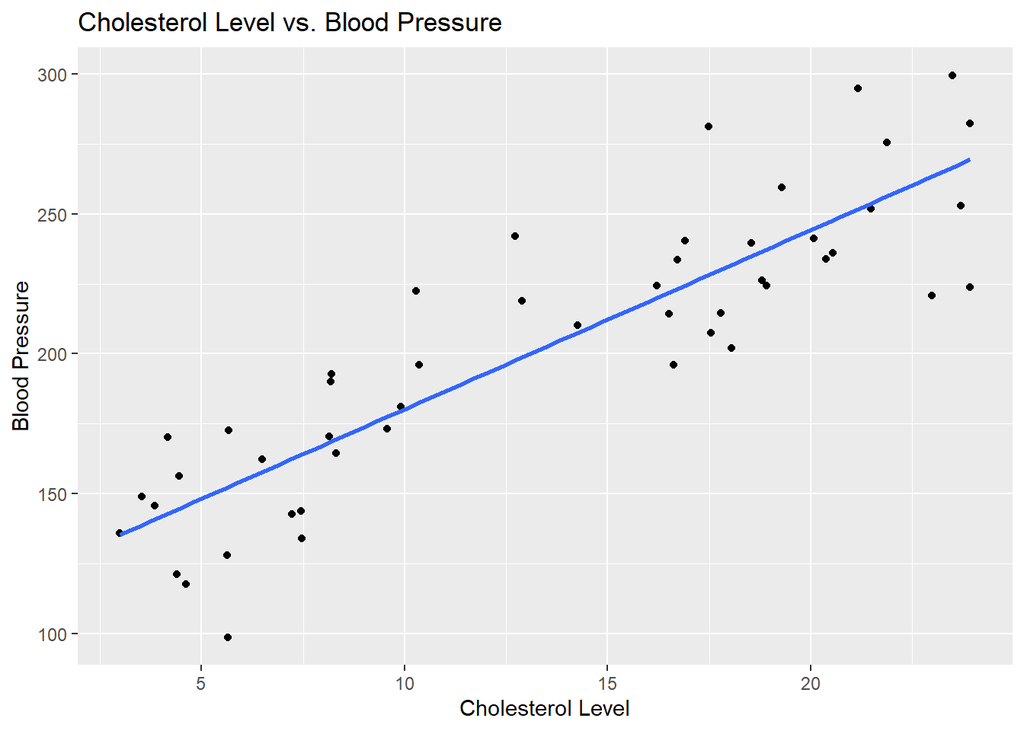

```r
# Perform simple linear regression

hypertension_model <- lm(blood_pressure ~ cholesterol_level, data=hypertension_data)


# Visualize the regression
ggplot(hypertension_data, aes(x= cholesterol_level , y=blood_pressure )) +
  geom_point() +
  labs(title="Cholesterol Level vs. Blood Pressure", x="Cholesterol Level", y="Blood Pressure")+
  geom_smooth(method="lm", se=FALSE)
```

Great, we have successfully created our model, which is now a list containing 12 objects. You can execute this command “names()” to check the list of the objects. You will find the various components used in the model fitting. One of this components is the “residuals” which we will need to evaluate assumptions in just a moment.

```r
names(hypertension_model)
```

```
##  [1] "coefficients"  "residuals"     "effects"       "rank"
##  [5] "fitted.values" "assign"        "qr"            "df.residual"
##  [9] "xlevels"       "call"          "terms"         "model"
```

### **Evaluate the assumptions**

Next, we are going to generate diagnostic plots. There are various methods for creating these plots.

**One method** involves combining the components such as the residuals and fitted values, and organizing them into a data frame. You can then utilize ggplot2, qqplot, or similar functions to create these plots.

**Another approach** is to use the plot function in base R to generate these visualizations. You might recall this method involves calling plot on the model object, such as “plot(hypertension_model)”.

```
plot(hypertension_model)
```

Before we proceed, ensure that you have the ggfortify package installed. You can do so by running the following code:

```r
# Install ggfortify package if not already installed
# The code if (!require(ggfortify)) is used to check whether the ggfortify package is already installed in your R environment. Let's break down what it does:

# require(ggfortify): This part checks if the ggfortify package is available and can be loaded. If the package is already installed, require() returns TRUE, indicating that the package is ready for use.

# ! (exclamation mark): This symbol is a logical NOT operator. It negates the result of the require() function. So, if the package is already loaded, !require(ggfortify) will be FALSE.

# The overall effect is that the code checks whether the ggfortify package is not already installed. If it's not installed (!require(ggfortify) is TRUE), then the code proceeds to the next part, which is installing the package using install.packages("ggfortify").

if (!require(ggfortify)) {
  install.packages("ggfortify")
}
```

Once you have installed the package, we can proceed to create the diagnostic plots:

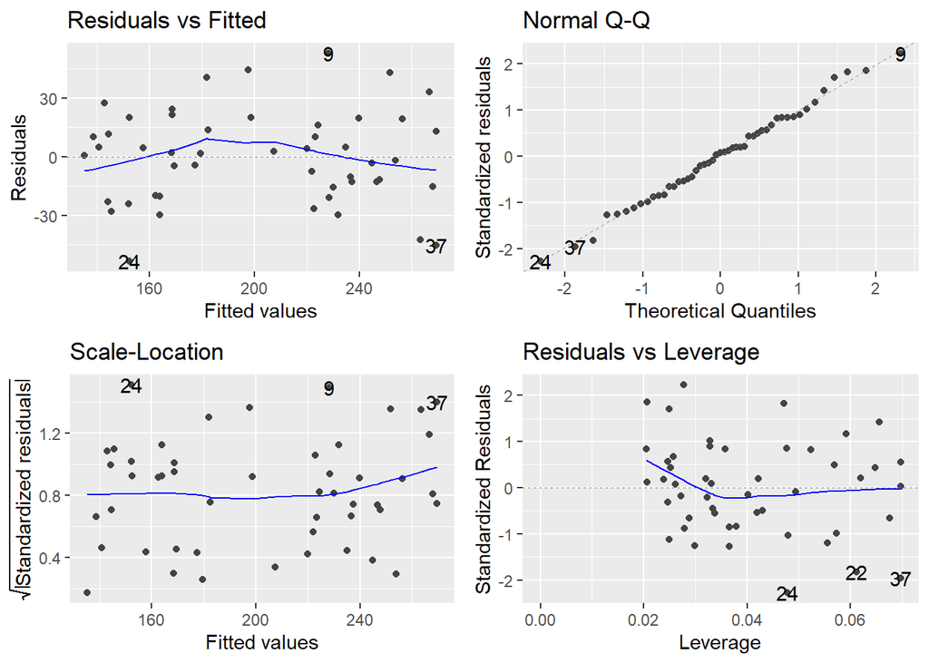

```r
# Load the necessary libraries
library(ggfortify)

# Generate diagnostic plots using autoplot
autoplot(hypertension_model)
```

Running the autoplot(hypertension_model) command produced a ggplot picture with four diagnostic plots.

For the **residuals versus fitted values plot**, our assumption is around the **linearity** of the data model. We are testing whether the relationship we are trying to establish or assume between the variables is acceptable. If the assumption holds, we should not observe any significant patterns, shapes, or cycles in the plots. Any such patterns could indicate nonlinear relationships within the data.

The second assumption we assess is the **normality** of the residuals, which we examine through the **Q-Q plot**. As observed, this plot shows an excellent fit. Note that the points on the plot represent the residuals, and the dashed line represents the expected distribution for normality. The fact that the points closely follow this line indicates that the residuals adhere to a normal distribution.

**The scale-location plot** is associated with the assumption of **equal variance**. What we expect to see here is a relatively consistent scatter of points without any pronounced patterns or unusual shapes. A violation of the equal variance assumption might manifest as a noticeable bent line shape in the plot.

The reference lines in these plots which are also often referred to as “panic lines.” help us assess patterns more easily. To remove these lines in the autoplot function, you can add the option smooth.colour = NA

```
# Generate a scale-location plot without smoothing

autoplot(hypertension_model, which=3, smooth.colour = NA )
```

**Note** that the slight hump shape or fluctuations detected in the plots is not a problem. It is essential to understand that minor variations like these are quite common and do not necessarily indicate a critical issue. However, what is crucial is that these variations remain relatively constant across the range. Our primary focus is to ensure the model’s reliability in making predictions within the range of our data. Only when we intend to make predictions beyond our data’s scope, do we need to be particularly concerned about these assumptions. In this case, the assumptions appear to be in good shape, indicating that the model is working well.

### **Make inference and evaluate guesses**

Now, we will summarize our model inference, to check an overview of the regression model’s inference, including coefficients, significance levels, and goodness-of-fit statistics, using summary (). We will also check whether we have got our guesses right.

```r
# Summarize model inference

summary(hypertension_model)
```

```
##
## Call:
## lm(formula = blood_pressure ~ cholesterol_level, data = hypertension_data)
##
## Residuals:
##    Min     1Q Median     3Q    Max
## -53.65 -15.68   1.58  16.01  53.02
##
## Coefficients:
##                   Estimate Std. Error t value Pr(>|t|)
## (Intercept)       116.0761     7.7030   15.07   <2e-16 ***
## cholesterol_level   6.4112     0.5119   12.53   <2e-16 ***
## ---
## Signif. codes:  0 '***' 0.001 '**' 0.01 '*' 0.05 '.' 0.1 ' ' 1
##
## Residual standard error: 24.13 on 47 degrees of freedom
## Multiple R-squared:  0.7695, Adjusted R-squared:  0.7646
## F-statistic: 156.9 on 1 and 47 DF,  p-value: < 2.2e-16
```

We will generate a table of variance with anova() function. It is important to clarify that the anova function does not actually perform a traditional Analysis of Variance (ANOVA). Instead, it evaluates the linear model and produces an ANOVA table. This table includes various statistics, such as sums of squares, mean squared errors, the F-value, and test significance.

```r
# Perform ANOVA on the linear model
anova_result <- anova(hypertension_model)

# Display the ANOVA table
print(anova_result)
```

```
## Analysis of Variance Table
##
## Response: blood_pressure
##                   Df Sum Sq Mean Sq F value    Pr(>F)
## cholesterol_level  1  91315   91315  156.89 < 2.2e-16 ***
## Residuals         47  27356     582
## ---
## Signif. codes:  0 '***' 0.001 '**' 0.01 '*' 0.05 '.' 0.1 ' ' 1
```

The ANOVA table provides insights into the variance and significance of variables in our model.

Again, the ANOVA table presents an analysis of variance. It declares our response variable as blood_pressure and provides relevant results and output. Specifically, you can see that the “cholesterol_level” variable significantly captures a substantial amount of variation, as indicated by the large total sums of squares and small residuals sums of squares. Additionally, the total mean squared values for the variable and the residuals mean squared values are notably different in size.

**Note** that the total sum of squares (TSS) measures how much variation there is in the observed data, while the residual sum of squares measures the variation in the error between the observed data and modeled values.

The F value or F ratio is the ratio of two mean square values. If the null hypothesis is true, you expect F to have a value close to 1.0 most of the time. A large F ratio means that the variation among group means is more than you’d expect to see by chance.

The F-value informs us about the degree of influence that our model has in its current form. What it tells us is that the amount of variation explained by cholesterol is substantial relative to what remains unexplained. Our model, which relates blood pressure to cholesterol level, captures a significant portion of the variation while leaving very little unaccounted for.

This ratio is represented by the F-value, and it indicates how well our model fits the data and captures variation.

Now, concerning the likelihood of obtaining an F-value as large as this (or even larger) under the null hypothesis that there is no effect, it is extremely small.

The associated p-value confirms this.

**Now to our guesses**, remember the guess is the gradient is 8, and the intercept is 135.

From the summary table, the estimated intercept, 116.0761, is quite close to the earlier guess, which was approximately 135. Superbly, our estimated gradient (slope) stands at 6.4, which is also not far from our initial rough estimate of 8.